# LO11

Billy

2022-08-26

# LO11, Confidence Intervals, Rejection regions and Critical values

## Random Variable Basics

- a random variable is a mathematical object which takes certain values with certain probabilities
- we have *discrete* and *continuous* random variables although we can always approximate a continous one with a discrete one
- A simple discrete random variable X can be described as a *single random* draw from a “box” containing tickets, each with numbers written on variable
  - F(X) = $\mu$ (the average of numbers in the box)
  - Var(X) = $\sigma^{2}$ (the population *variance* of the numbers in the box)
  - SD(X) = $\sigma$

## Random sample with replacement

- consider a sample with size n written as $X_{1},X_{2}, ... , X_{n}$
- this means all possible samples of size n is chosen in such a way that each is equally likely
- if there are N tickets in a box, how many such samples are there
- It turns out that these X’s are *independent and identically distributed*. This means:
  - each X has the sample distribution as a single draw
  - The X’s are all mutually independent
- Consider now taking the total $T=\sum_{i=1}^{n} X^i$
- What is E(T)?
- What is Var(T)?

## Expectations and Variance of sums

The expectation is always the sum of the expectations

$$E(T) = E(X_{1} + X_{2} ... + X_{n}) =
\mu \times n$$
Variance is the sum of independent random variables - The variance of a sum is not always the sum of the variances However, it is if the X’ are independent:

$$Var(T) = Var(X_{1} + X_{2} ... + X_{n})
= \sigma^{2} \times n$$

Multiplying by a constant for any random variable X and any constant c

$$E(cX) = c(E(X)$$
and
$$Var(cX) = c^{2}(Var(X))$$

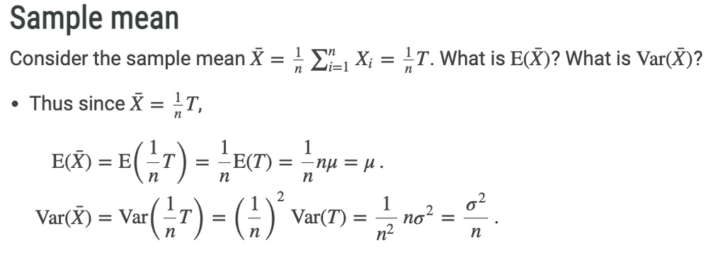

## Estimating

- in many applications we take data and we are interested in *estimating* or *learning*
- in this case, the *estimator* is the sample mean: $\bar{X}$
- This estimate is $\bar{x} = \sum_{i=1}^{n}x^{i}$, the observed value of the mean of the data (this is differnt to $bar{X}$)
- An important theoretical quantity is the *standard error*, the *standard deviation* of the estimator
  $$SF = SD(\bar{X}) = \sqrt{(Var{\bar{X}})} =
  \frac{\sigma}{\sqrt{n}}$$

This is (in general) also an *unknown parameter*

## Importance of Standard Error

- The standard error (standard deviation of the estimator) is important to know, since it tells us the “likely size of the estimation error”.
- An estimate on its own is not very useful, we need to also know how accurate or reliable the estimate is.
  - This is what the standard error provides.
- Unfortunately in most contexts the standard error is also unknown;
  - but we can usually (also) estimate the standard error!

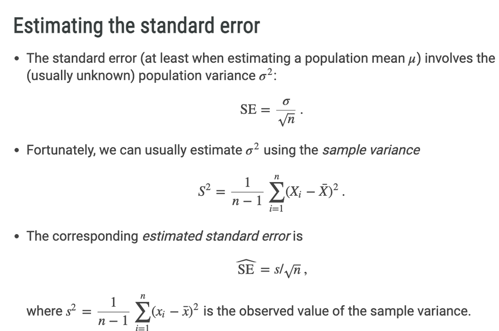

# Critical Values and Confidence Intervals

## More precise inference

- Usually, we want to know if a given value $\mu_0$ is a “plausible value” for the unknown $\mu$, based on observed data $x_1,…,x_n$.

Roughly speaking, we do this by

1. computing the value of the *estimate* $\bar{x}$;
2. computing the value of the *estimated standard error* $\frac{s}{\sqrt{n}}$;
3. seeing if the discrepancy $\bar{x}$ − $\mu_0$ is “large” compared to the standard error.

The various procedures we look at:

- t-tests (with corresponding p-values)
  - confidence intervals
  - rejection regions
  - are all variations on this single idea.

## What kind of discrepancies are of interest?

We need to have it very clear in our minds which kind of discrepancies $ x -_0$ we are interested in:

- positive
- negative
- both

Another way to think about it is, given a fixed $\mu_0$ of interest and an observed sample mean $\bar{x}$, which of the following questions are we asking:

- Is $\bar{x}$ significantly more than $\mu_0$? (one-sided)
- Is $\bar{x}$ significantly less than $\mu_0$? (one-sided)
- Is $\bar{x}$ significantly different to $\mu_0$? (two-sided)

### Example Beer Contents

Beer contents in a 6 pack in milliliters are : 374.8, 375.0, 375.3, 374.8, 374.4, 374.9

*Does the mean beer content differ from the 375 ml claimed on the label?*

```r
x = c(374.8, 375.0, 375.3, 374.8, 374.4, 374.9)
mean(x)
```

```
## [1] 374.8667
```

```r
sd(x)
```

```
## [1] 0.294392
```

- for consumers, the only interest they have is if bottles are being *underfilled*
- for producer, they dont want to be *underfilling* or *overfilling*
- thus a one sided and two sided POV are interesting for this example

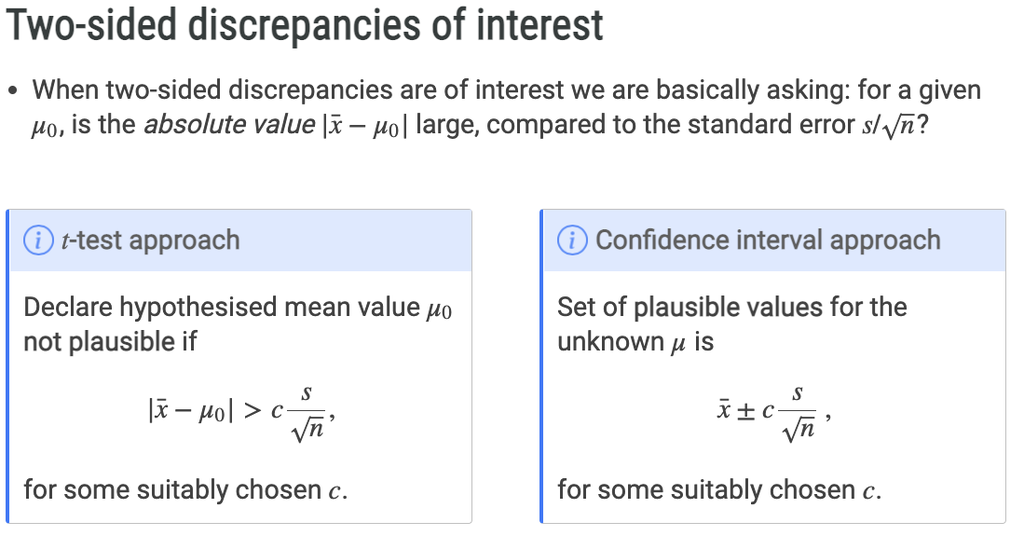

## How to choose the constant c?

- The constant c can be chosen in a sensible way in each context.
- **Testing:** control the *false alarm rate*.
- **Confidence intervals:** *control the coverage probability*;
  - the coverage probability is commonly also called the confidence level and expressed as a percentage.